# Machine Learning Course Project

Toby Wright

9/12/2019

# Background

Using devices such as Jawbone Up, Nike FuelBand, and Fitbit it is now possible to collect a large amount of data about personal activity relatively inexpensively. These type of devices are part of the quantified self movement – a group of enthusiasts who take measurements about themselves regularly to improve their health, to find patterns in their behavior, or because they are tech geeks. One thing that people regularly do is quantify how much of a particular activity they do, but they rarely quantify how well they do it. In this project, your goal will be to use data from accelerometers on the belt, forearm, arm, and dumbell of 6 participants. They were asked to perform barbell lifts correctly and incorrectly in 5 different ways. More information is available from the website here: http://web.archive.org/web/20161224072740/http:/groupware.les.inf.puc-rio.br/har (see the section on the Weight Lifting Exercise Dataset).

# Data

The training data for this project are available here:

https://d396qusza40orc.cloudfront.net/predmachlearn/pml-training.csv

The test data are available here:

https://d396qusza40orc.cloudfront.net/predmachlearn/pml-testing.csv

The data for this project come from this source: http://web.archive.org/web/20161224072740/http:/groupware.les.inf.puc-rio.br/har. If you use the document you create for this class for any purpose please cite them as they have been very generous in allowing their data to be used for this kind of assignment.

# Plan

For this project I aim to predict the classe variable, to do this I plan to use random forests. Then I will test this model on the testing set of 20 observations.

# Load Packages and read in data

Seed set to 245.

```r
library(caret)
library(rattle)
library(randomForest)
library(dplyr)
library(ggplot2)
library(rpart)
library(rpart.plot)
library(rattle)
library(knitr)

set.seed(245)

training = read.csv("pml-training.csv", na.strings=c("NA","#DIV/0!", ""))
testing = read.csv("pml-testing.csv", na.strings=c("NA","#DIV/0!", ""))
```

# Clean Data

```r
# remove any column with all NA values
training = training[,colSums(is.na(training)) == 0]
testing = testing[,colSums(is.na(testing)) == 0]

# remove columns that are not relevant to prediction user_name, raw_timestamp_part_1, raw_timestamp_part_,2 cvtd_timestamp, new_window, and  num_window (columns 1 to 7).
training = training[,-c(1:7)]
testing = testing[,-c(1:7)]

# create data partition for training set

intrain = createDataPartition(y= training$classe, p = 0.7, list = F)

trainingset = training[intrain,]
testingset = training[-intrain,]
```

# Random Forest Model

```r
model = randomForest(classe ~., data = trainingset)
print(model)
```

```
##
## Call:
##  randomForest(formula = classe ~ ., data = trainingset)
##                Type of random forest: classification
##                      Number of trees: 500
## No. of variables tried at each split: 7
##
##         OOB estimate of  error rate: 0.43%
## Confusion matrix:
##      A    B    C    D    E  class.error
## A 3905    0    0    0    1 0.0002560164
## B   11 2643    4    0    0 0.0056433409
## C    0   11 2383    2    0 0.0054257095
## D    0    0   18 2232    2 0.0088809947
## E    0    0    3    7 2515 0.0039603960
```

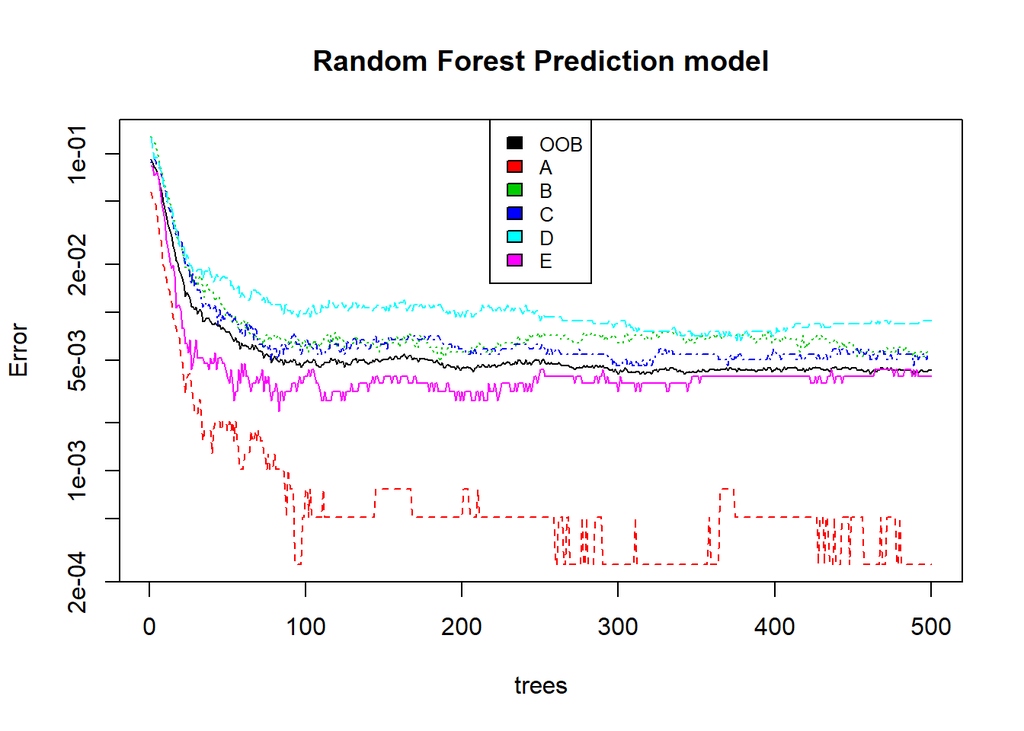

```r
plot(model, log = 'y', main= "Random Forest Prediction model")
legend("top", colnames(model$err.rate),col=,cex=0.8,fill=1:6)
```

# Predicting using the testing set

```r
predicting = predict(model, testingset, type = 'class')
confusionMatrix(predicting, testingset$classe)
```

```
## Confusion Matrix and Statistics
##
##           Reference
## Prediction    A    B    C    D    E
##          A 1672    3    0    0    0
##          B    2 1136    6    0    0
##          C    0    0 1013    8    0
##          D    0    0    7  954    6
##          E    0    0    0    2 1076
##
## Overall Statistics
##
##                Accuracy : 0.9942
##                  95% CI : (0.9919, 0.996)
##     No Information Rate : 0.2845
##     P-Value [Acc > NIR] : < 2.2e-16
##
##                   Kappa : 0.9927
##
##  Mcnemar's Test P-Value : NA
##
## Statistics by Class:
##
##                      Class: A Class: B Class: C Class: D Class: E
## Sensitivity            0.9988   0.9974   0.9873   0.9896   0.9945
## Specificity            0.9993   0.9983   0.9984   0.9974   0.9996
## Pos Pred Value         0.9982   0.9930   0.9922   0.9866   0.9981
## Neg Pred Value         0.9995   0.9994   0.9973   0.9980   0.9988
## Prevalence             0.2845   0.1935   0.1743   0.1638   0.1839
## Detection Rate         0.2841   0.1930   0.1721   0.1621   0.1828
## Detection Prevalence   0.2846   0.1944   0.1735   0.1643   0.1832
## Balanced Accuracy      0.9990   0.9978   0.9928   0.9935   0.9970
```

```r
ose <- 1 - as.numeric(confusionMatrix(testingset$classe, predicting)$overall[1])
ose
```

```
## [1] 0.0057774
```

# Predicting the 20 classes from the testing data

```r
testing$classe = predict(model, testing)

kable(testing$classe)
```

| x |
| --- |
| B |
| A |
| B |
| A |
| A |
| E |
| D |
| B |
| A |
| A |
| B |
| C |
| B |
| A |
| E |
| E |
| A |
| B |
| B |
| B |